# Análisis Multivariado - Clase 6

2025-04-25

## Proyecciones

## Simulación

[interactive chart not shown]

## Proyección sobre el plano xy

[interactive chart not shown]

## Proyección sobre el plano xz

[interactive chart not shown]

## Proyección sobre el plano yz

[interactive chart not shown]

## Matriz de covarianza

Si vemos la matriz de covarianza de estos datos, observamos lo siguiente:

```
##            x           y           z
## x  0.9651928 -0.04858300  0.01647620
## y -0.0485830  2.96418772 -0.02802657
## z  0.0164762 -0.02802657  5.07255680
```

Notar que las variables de mayor varianza son \(y\) y \(z\). Por eso se observa que los datos quedan mejor representados al proyectarlos sobre ese plano.

## Otra simulación

[interactive chart not shown]

## Matriz de covarianza

Viendo la matriz de covarianza, si quisiéramos aplicar el mismo criterio, deberíamos proyectar sobre el plano \(xz\)

```
##            x          y        z
## x 3.85368694 0.01017675 1.430900
## y 0.01017675 2.34222557 1.254954
## z 1.43090004 1.25495359 2.806025
```

## Proyección sobre el plano xy

[interactive chart not shown]

## Proyección sobre el plano xz

[interactive chart not shown]

## Proyección sobre el plano yz

[interactive chart not shown]

## Reformulación

Vemos que, como habíamos dicho, la proyección sobre el plano \(xz\) parece ser el que mejor se adapta a las observaciones entre las tres propuestas. Sin embargo, ninguna de las proyecciones termina representando bien a los datos.

Uno de los posibles motivos puede ser porque sólo estamos considerando selecciones de dos variables, obligando a que los planos considerados estén alineados con los ejes, cuando vemos que los datos parecen presentar una inclinación. Por lo tanto, podríamos elegir 2 **combinaciones** de variables más que dos variables aisladas.

El problema es que hay infinitas combinaciones posibles, lo cual lleva a que sea difícil seleccionarlas. Sin embargo, sabemos donde está la clave: en la matriz de covarianza.

## Autovalores y autovectores

Consideremos la primer matriz de covarianza:

```
##            x           y           z
## x  0.9651928 -0.04858300  0.01647620
## y -0.0485830  2.96418772 -0.02802657
## z  0.0164762 -0.02802657  5.07255680
```

Sus autovalores son:

```
## [1] 5.0730007 2.9649846 0.9639521
```

Sus autovectores asociados son:

```
##              [,1]        [,2]         [,3]
## [1,]  0.004168856  0.02417365  0.999699082
## [2,] -0.013384946 -0.99961686  0.024227474
## [3,]  0.999901727 -0.01348192 -0.003843696
```

## Autovalores y autovectores

Consideremos la segunda matriz de covarianza:

```
##            x          y        z
## x 3.85368694 0.01017675 1.430900
## y 0.01017675 2.34222557 1.254954
## z 1.43090004 1.25495359 2.806025
```

Sus autovalores son:

```
## [1] 5.0730007 2.9649846 0.9639521
```

Sus autovectores asociados son:

```
##           [,1]       [,2]       [,3]
## [1,] 0.7299798  0.5915162  0.3424005
## [2,] 0.2876438 -0.7203330  0.6311746
## [3,] 0.6199924 -0.3622553 -0.6959745
```

## Observaciones

Notar que los autovalores de ambas matrices de covarianza son exactamente iguales.

En el primer caso, la proyección sobre el plano \(yz\) daba un buen resultado porque justamente los 2 autovectores asociados a los mayores autovalores están muy alineados con ese plano.

Sin embargo, en el segundo caso, no se respetaron la dirección que indicaban los autovectores. Por lo tanto, vamos a intentar proyectar los datos sobre los primeros dos autovectores para ver si los datos quedan mejor representados.

## Proyección sobre autovectores

[interactive chart not shown]

## PCA

## Componentes principales

A los autovectores de la matriz de covarianza se los llama componentes principales. Aquellos autovectores asociados a mayores autovalores son los que mejor explican la heterogeneidad de los datos. Por eso, los componentes principales se ordenan según sus autovalores de mayor a menor.

## Output principal

Para el segundo ejemplo, notemos que `R` nos devuelve los componentes principales y sus correspondientes desvíos estándard:

```r
pca_MVnorm_2
```

```
## Standard deviations (1, .., p=3):
## [1] 2.2523323 1.7219131 0.9818106
##
## Rotation (n x k) = (3 x 3):
##         PC1        PC2        PC3
## x 0.7299798 -0.5915162 -0.3424005
## y 0.2876438  0.7203330 -0.6311746
## z 0.6199924  0.3622553  0.6959745
```

## Autovalores

Pareciera ser que no coinciden los valores de los desvíos obtenidos con los autovalores, pero veamos que cuando se elevan al cuadrado, coinciden con los autovalores de la matriz de covarianza:

```r
print(pca_MVnorm_2$sdev^2)
```

```
## [1] 5.0730007 2.9649846 0.9639521
```

```r
print(eigMV_2$values)
```

```
## [1] 5.0730007 2.9649846 0.9639521
```

## Autovectores

Vemos también cómo coinciden los autovectores de la matriz de covarianza con los componentes principales (salvo cambios en los signos):

```r
print(pca_MVnorm_2$rotation)
```

```
##         PC1        PC2        PC3
## x 0.7299798 -0.5915162 -0.3424005
## y 0.2876438  0.7203330 -0.6311746
## z 0.6199924  0.3622553  0.6959745
```

```r
print(eigMV_2$vectors)
```

```
##           [,1]       [,2]       [,3]
## [1,] 0.7299798  0.5915162  0.3424005
## [2,] 0.2876438 -0.7203330  0.6311746
## [3,] 0.6199924 -0.3622553 -0.6959745
```

## Datos transformados

El output permite ver cómo quedan representados los datos originales en los nuevos componentes principales, en el sentido de con qué múltiplos de cada componente se obtiene la observación original:

- Primer dato transformado

```
##          PC1          PC2          PC3
## -0.311249397 -0.009908017  1.302364472
```

- Primer dato original

```
##            x          y         z
## 1 -0.7118779 -0.9440517 0.6771001
```

- Primer dato transformado x Componentes principales

```
##               x          y         z
## [1,] -0.7118779 -0.9440517 0.6771001
```

## Análisis gráficos

## Datos simulados

```
##   Hidratación Alimentación Pantallas     Sueño      Test  Puntaje
## 1    94.69166     99.93649 113.06284  98.97909 Cognitivo 170.7152
## 2    97.82053     82.96936  91.43642 109.86590 Cognitivo 237.2545
## 3   101.56877    106.46284  94.15598 109.33415    Físico 184.1585
## 4   101.93731     94.56491  91.99778  73.55282 Cognitivo 162.9955
## 5    95.64230    106.28775  94.37241 102.26507 Cognitivo 217.0881
## 6    97.10112    107.53681  98.54202 107.97426 Cognitivo 218.3447
```

## Estandarización

Es importante estandarizar previamente los datos, ya que en caso contrario, las variables de mayor variabilidad guiarán el resultado y opacarán a las otras:

```r
pca_Sim_sc=prcomp(DatSim[-5], center = TRUE, scale. = TRUE)
```

## Varianza explicada

Una forma de decidir cuántos componentes principales tomar es observar en qué componente principal se acumula una varianza de los datos considerada deseable según el problema.

```
## Importance of components:
##                           PC1    PC2    PC3    PC4     PC5
## Standard deviation     1.3318 1.0257 0.9786 0.9639 0.53639
## Proportion of Variance 0.3547 0.2104 0.1915 0.1858 0.05754
## Cumulative Proportion  0.3547 0.5651 0.7566 0.9425 1.00000
```

## Scree plot

Otra forma de decidir es con un criterio gráfico, cuando se ve que la varianza correspondiente a las componentes dejan de ser significativas.

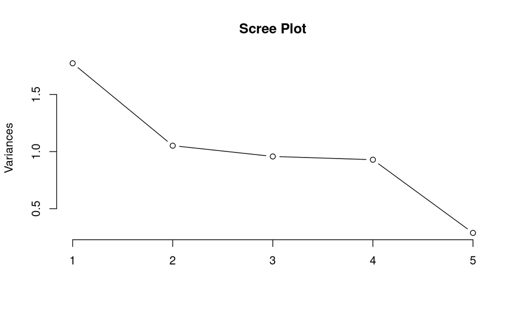

## Score plot

El score plot permite visualizar cómo se ubican las observaciones al proyectarlas sobre dos componentes principales:

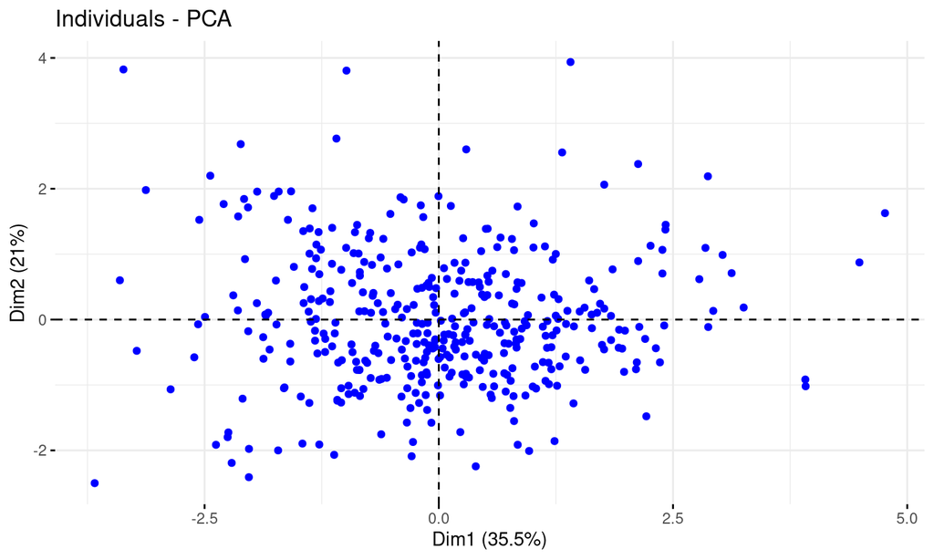

## Score plot (Con color)

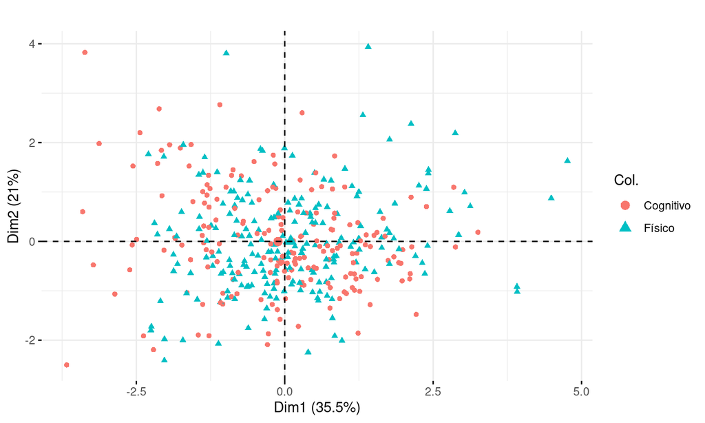

## Score plot (Grid)

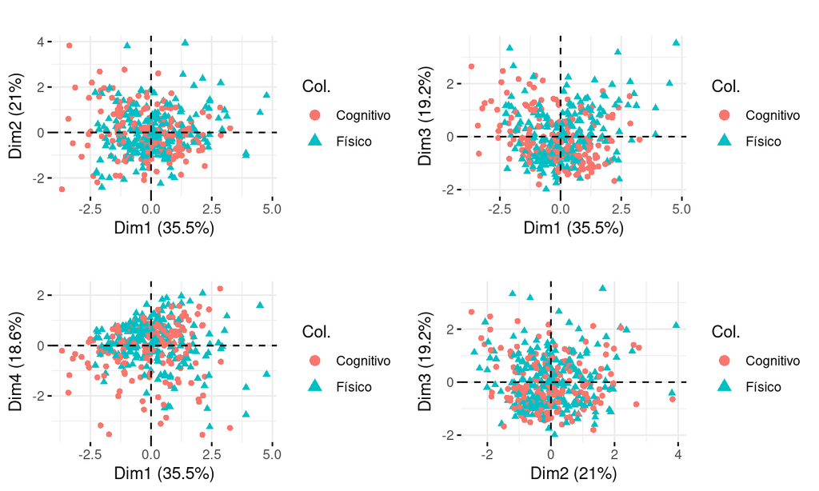

## Representación de observaciones

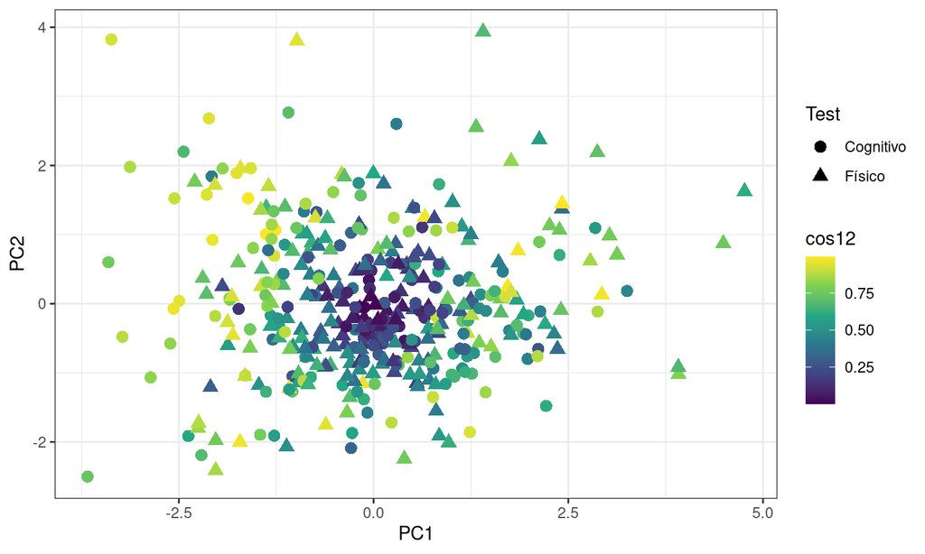

## Representación de observaciones (Grid)

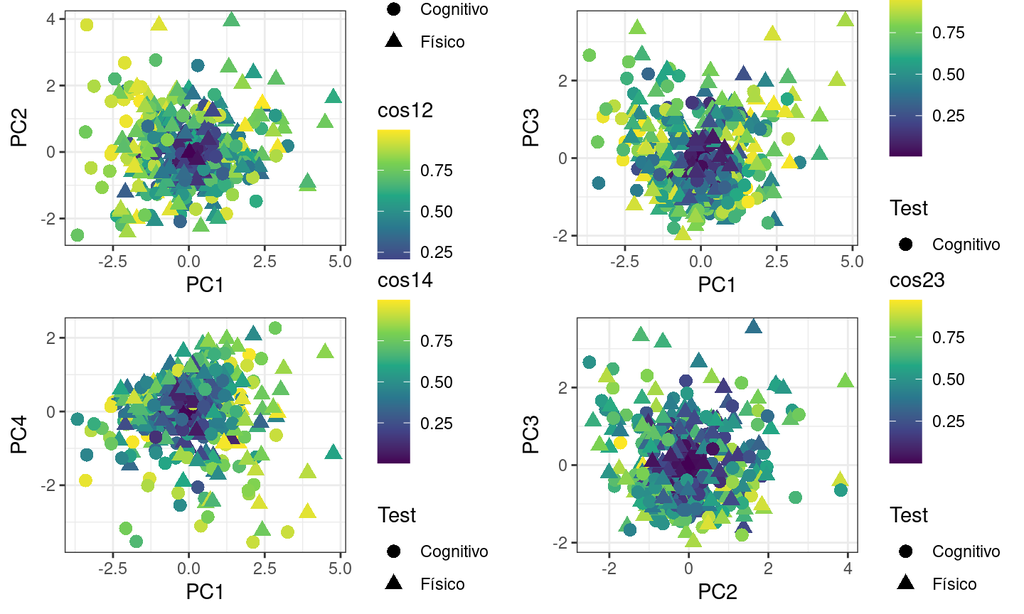

## Contribución de variables

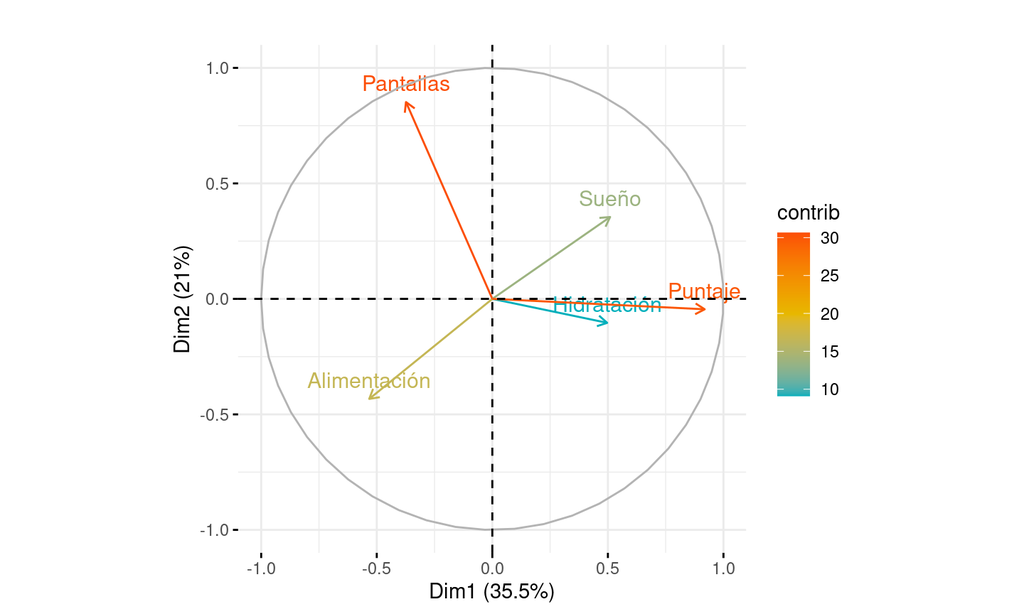

## Contribución de variables (Grid)

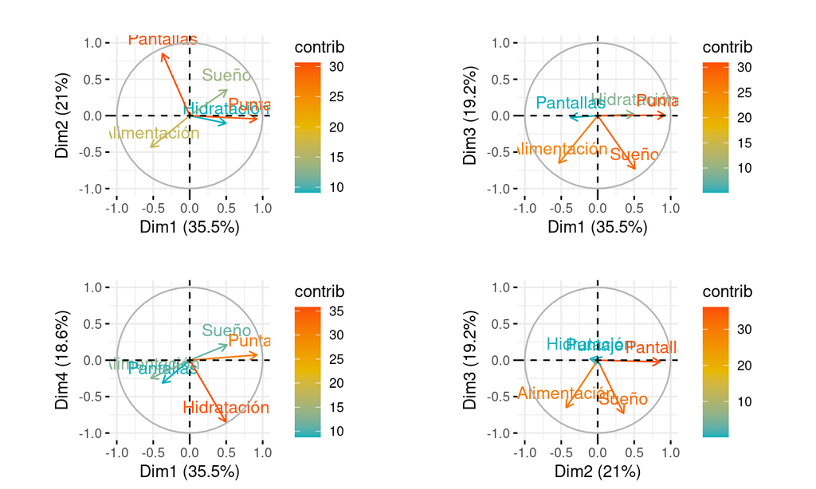

## Biplot

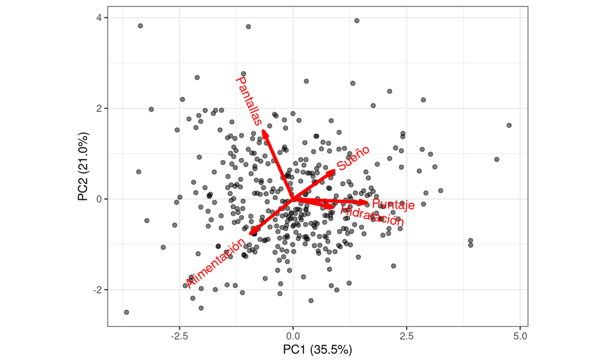

## Biplot (Grid)

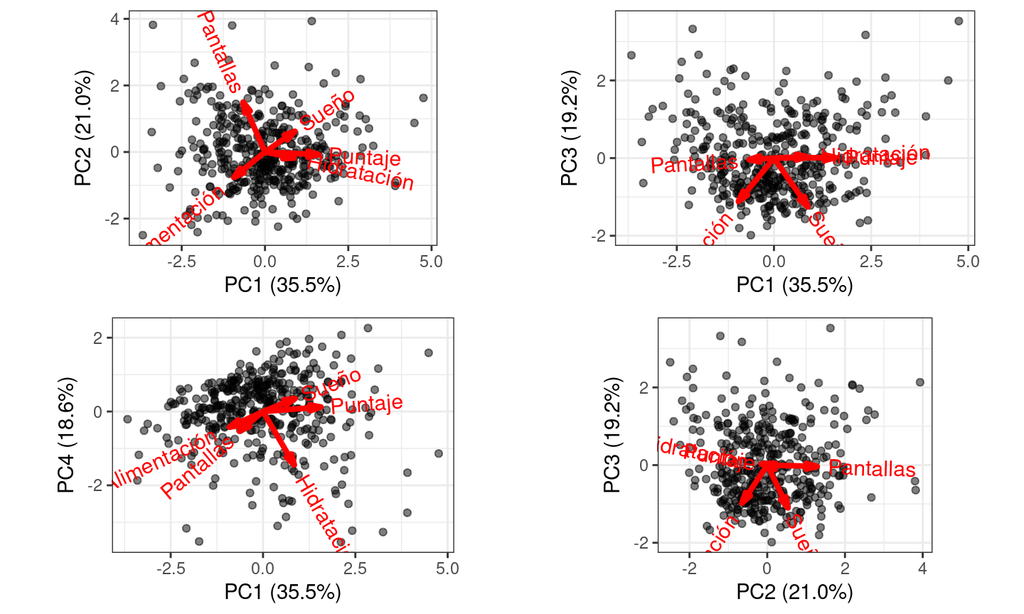

## Grupos divididos

## Datos (Test Físico)

[interactive chart not shown]

## PCA (Test Físico)

```
## Standard deviations (1, .., p=3):
## [1] 1.41618884 0.99694046 0.02277919
##
## Rotation (n x k) = (3 x 3):
##                     PC1           PC2        PC3
## Hidratación  -0.4765136  0.7401556096  0.4744517
## Alimentación  0.5238879  0.6724353728 -0.5228500
## Puntaje      -0.7060285 -0.0005856721 -0.7081832
```

## Varianza explicada (Test Físico)

```
## Importance of components:
##                           PC1    PC2     PC3
## Standard deviation     1.4162 0.9969 0.02278
## Proportion of Variance 0.6685 0.3313 0.00017
## Cumulative Proportion  0.6685 0.9998 1.00000
```

## Scree plot (Test Físico)

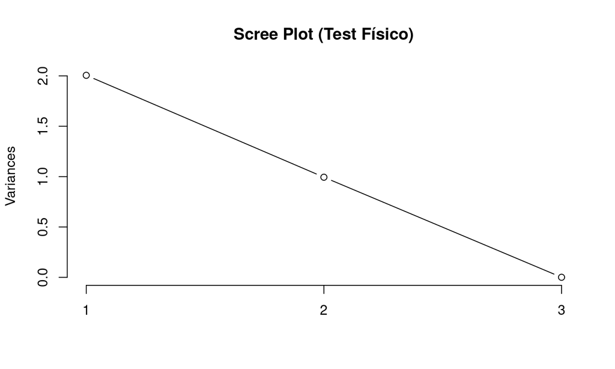

## Score plot (Test Físico)

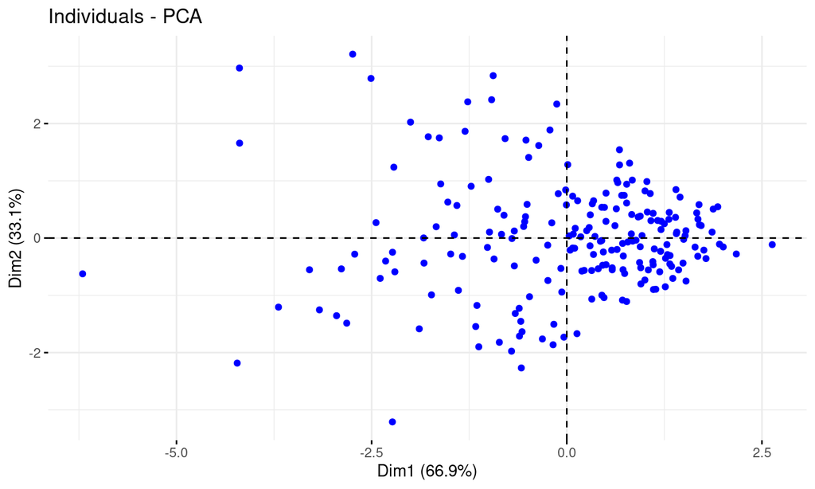

## Representación de observaciones (Test Físico)

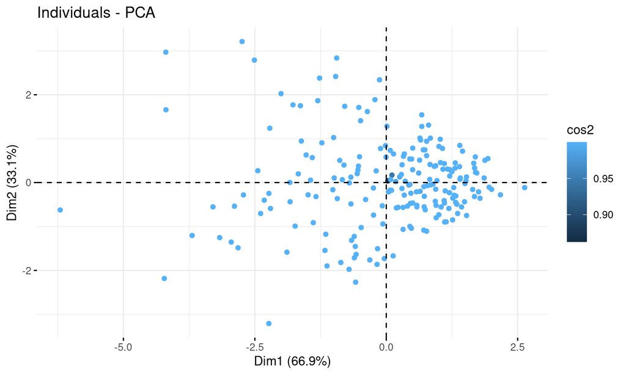

## Contribución de variables (Test Físico)

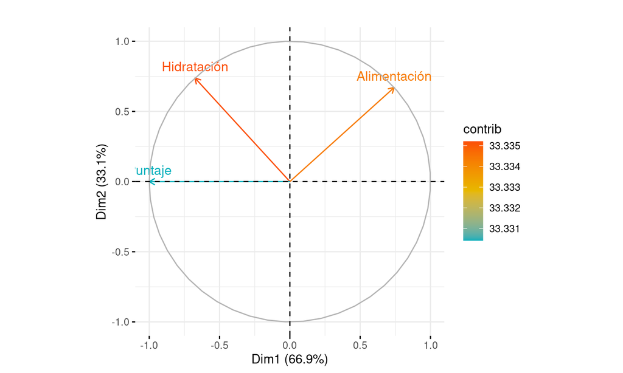

## Biplot (Test Físico)

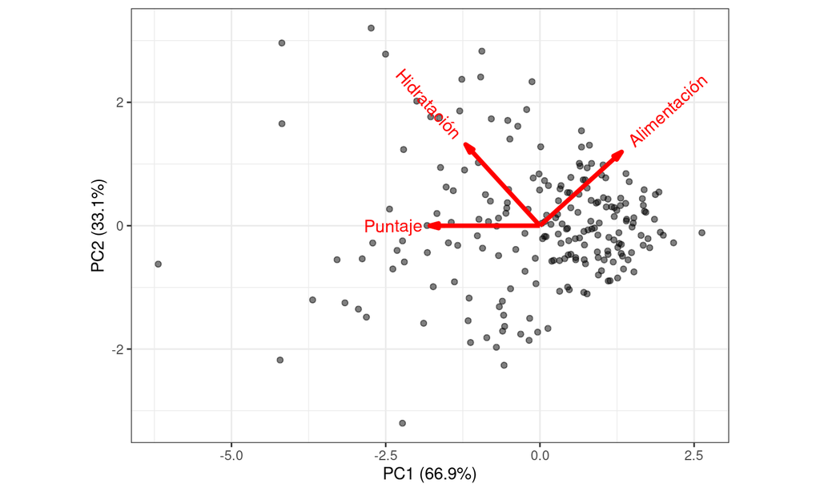

## Datos (Test Cognitivo)

[interactive chart not shown]

## PCA (Test Cognitivo)

```
## Standard deviations (1, .., p=3):
## [1] 1.40257368 1.01601525 0.02236253
##
## Rotation (n x k) = (3 x 3):
##                  PC1           PC2        PC3
## Pantallas -0.4901225  0.7147158492  0.4989601
## Sueño      0.5015694  0.6994145765 -0.5091634
## Puntaje    0.7128872 -0.0007107122  0.7012784
```

## Varianza explicada (Test Cognitivo)

```
## Importance of components:
##                           PC1    PC2     PC3
## Standard deviation     1.4026 1.0160 0.02236
## Proportion of Variance 0.6557 0.3441 0.00017
## Cumulative Proportion  0.6557 0.9998 1.00000
```

## Scree plot (Test Cognitivo)

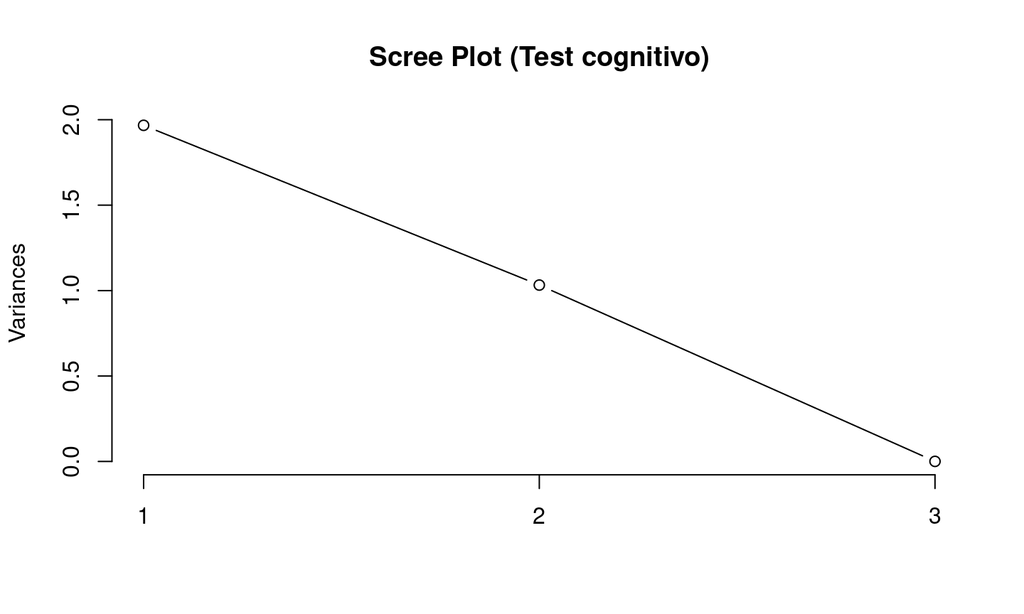

## Score plot (Test Cognitivo)

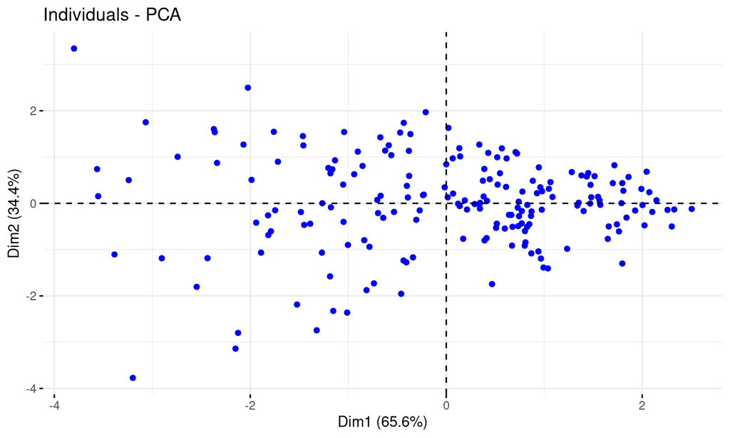

## Representación de observaciones (Test Cognitivo)

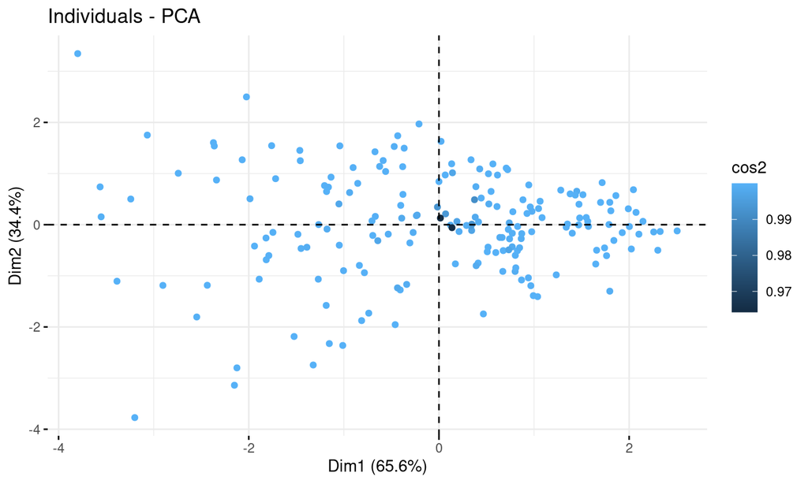

## Contribución de variables (Test Cognitivo)

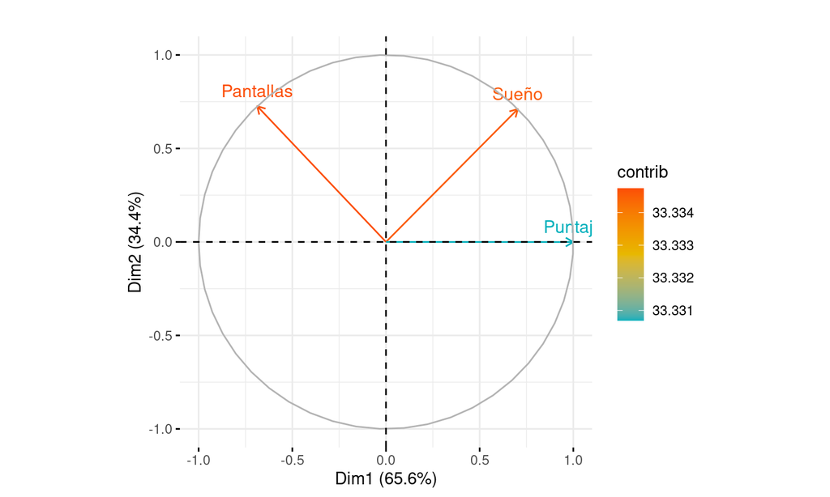

## Biplot (Test Cognitivo)

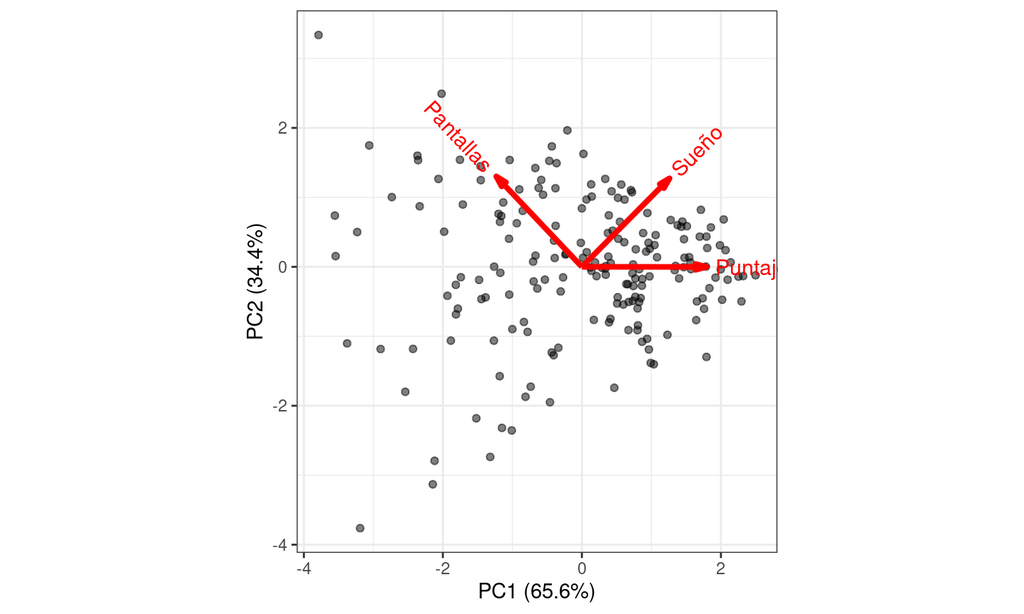

## Más ruido de otras variables (Test Físico)

```
## Standard deviations (1, .., p=5):
## [1] 1.42052374 1.02801915 1.00396369 0.95751612 0.02255436
##
## Rotation (n x k) = (5 x 5):
##                      PC1         PC2         PC3         PC4          PC5
## Hidratación   0.47377852  0.53938881  0.12928822  0.49275779 -0.474413260
## Alimentación -0.52037429  0.46960089  0.22263558  0.43113858  0.522722231
## Pantallas     0.04594702 -0.68955677  0.39591561  0.60468715 -0.002147862
## Sueño         0.10028155  0.11347813  0.87837771 -0.45333601 -0.002320511
## Puntaje       0.70183830  0.01299546 -0.07363002  0.01221512  0.708296216
```

```
## Importance of components:
##                           PC1    PC2    PC3    PC4     PC5
## Standard deviation     1.4205 1.0280 1.0040 0.9575 0.02255
## Proportion of Variance 0.4036 0.2114 0.2016 0.1834 0.00010
## Cumulative Proportion  0.4036 0.6149 0.8165 0.9999 1.00000
```

## Estandarizar

## PCA sin estandarización

```
## Standard deviations (1, .., p=5):
## [1] 283.184639  23.026026   9.758943   9.220926   5.672232
##
## Rotation (n x k) = (5 x 5):
##                     PC1        PC2         PC3         PC4        PC5
## Hidratación  -0.3518128  0.2123121 -0.34466572  0.30530279  0.7868590
## Alimentación -0.3522847  0.4216062 -0.05156892  0.63523756 -0.5403309
## Pantallas    -0.3527000  0.5489125 -0.24884800 -0.70144483 -0.1426450
## Sueño        -0.3539521  0.1641634  0.89480161 -0.05376252  0.2102569
## Puntaje      -0.7088327 -0.6700128 -0.12629702 -0.09136847 -0.1560124
```

## Varianza explicada

```
## Importance of components:
##                             PC1      PC2     PC3     PC4    PC5
## Standard deviation     283.1846 23.02603 9.75894 9.22093 5.6722
## Proportion of Variance   0.9908  0.00655 0.00118 0.00105 0.0004
## Cumulative Proportion    0.9908  0.99738 0.99855 0.99960 1.0000
```

## Scree Plot

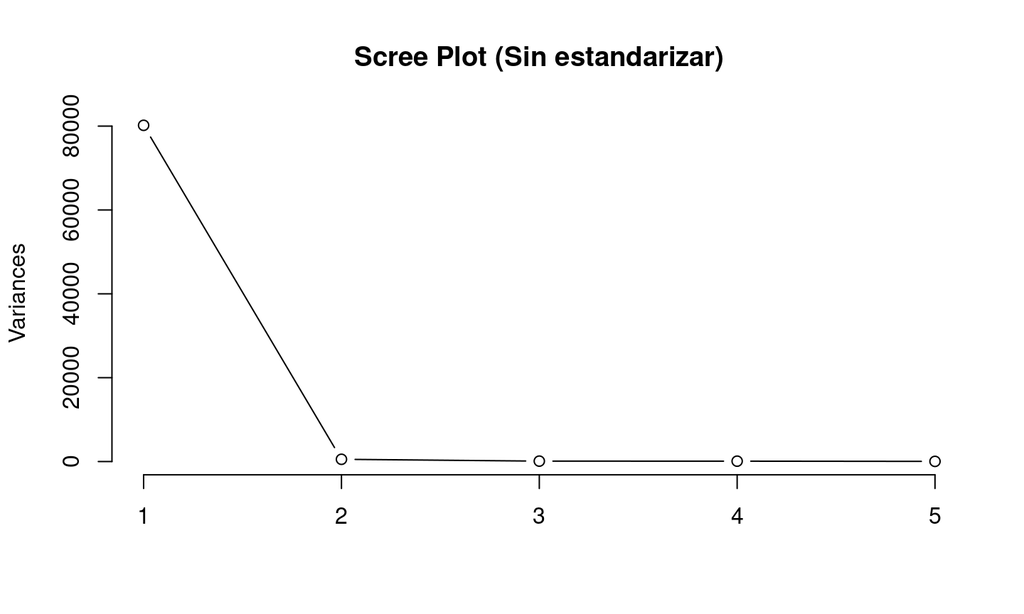

## Score Plot

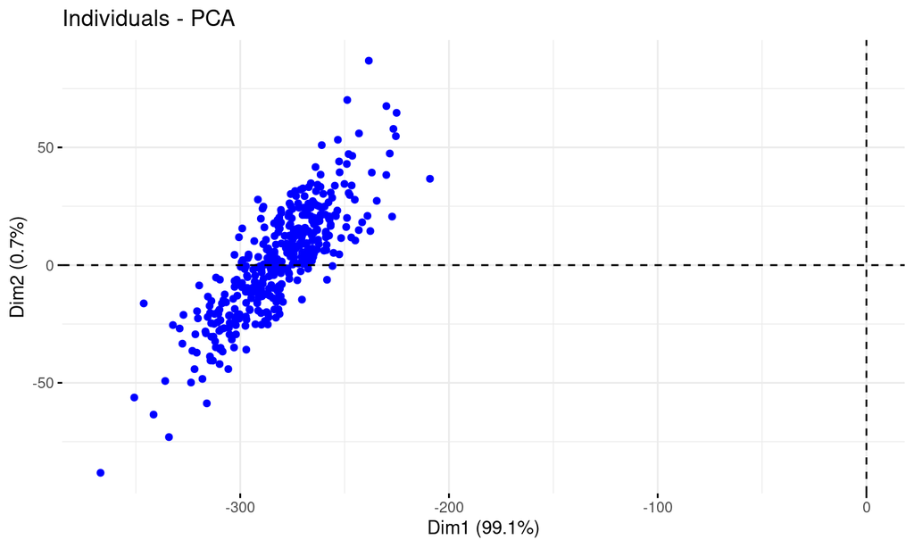

## Representación de observaciones

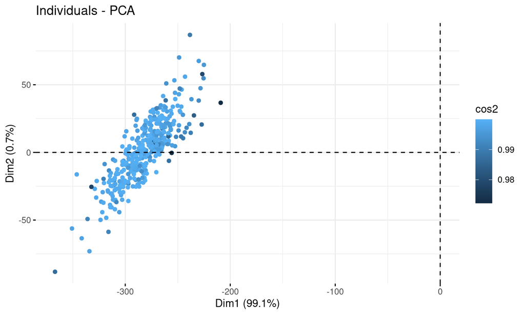

## Contribución de variables

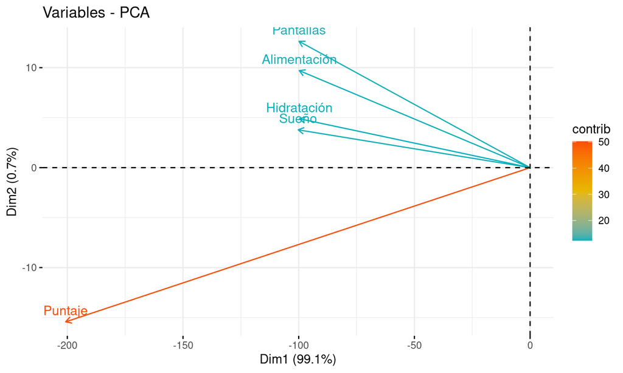

## Relación con SVD

## Matriz de covarianza

Recordar que otra forma de expresar la matriz de covarianza de un vector aleatorio \(\mathbf{X}\in \mathbb{R}^p\) es la siguiente: \[\Sigma=\text{Cov}(\mathbf{X})=E(\underset{columna}{\underbrace{(\mathbf{X}-\vec{\mu})^T}}\times \underset{fila}{\underbrace{(\mathbf{X}-\vec{\mu})}})\in \mathbb{R}^{p\times p} \]

Por lo tanto, si ya consideramos \(\widetilde{\mathbf{X}}=\mathbf{X}-\vec{\mu}\) como el vector centrado, obtenemos: \[\Sigma=\text{Cov}(\widetilde{\mathbf{X}})=E(\widetilde{\mathbf{X}}^T\times \widetilde{\mathbf{X}}) \] Para una matriz de datos centrada \(\widetilde{\mathbf{A}}\in \mathbb{R}^{n\times p}\), cuyas filas son datos de un vector aleatorio \(\widetilde{\mathbf{X}}\), se estima la matriz de covarianza \(\Sigma\) con del siguiente modo: \[\widehat{\Sigma}=\dfrac{\widetilde{\mathbf{A}}^T \times\widetilde{\mathbf{A}}}{n} \]

## Reducción de la dimensionalidad

Por lo tanto, si quisiéramos proyectar los datos sobre los primeros \(k<p\) componentes principales, podríamos considerar

- \(U_k\) las primeras \(k\) columnas de \(U\)
- \(S_k\) las primeras \(k\) columnas y \(k\) filas de \(S\)
- \(V_k\) las primeras \(k\) columnas de \(V\)

y se obtiene: \[\underset{n\times p}{\underbrace{\widetilde{\mathbf{A}}_k}}=\underset{n\times k}{\underbrace{U_k}}\times \underset{k\times k}{\underbrace{S_k}}\times \underset{k\times p}{\underbrace{V_k^T}} \]

Por lo tanto, se pueden tomar los datos de la matriz \(Z_k=U_k\times S_k\) como los múltiplos de los \(k\) componentes principales. En caso de querer reconstruir los datos originales, se multiplica \(Z_k\times V_k^T\)

## Ejemplo

[interactive chart not shown]

## Ejemplo (Descomposición)

```
##              [,1]          [,2]         [,3]
## [1,] -0.005217660 -0.0002506648  0.042238842
## [2,] -0.003539351  0.0204488322 -0.007604096
## [3,]  0.010007978 -0.0207916922 -0.061311380
```

```
##         [,1]     [,2]     [,3]
## [1,] 71.2148  0.00000  0.00000
## [2,]  0.0000 54.42457  0.00000
## [3,]  0.0000  0.00000 31.03321
```

```
##           [,1]       [,2]       [,3]
## [1,] 0.7299590 -0.5915889 -0.3423192
## [2,] 0.2877993  0.7203123 -0.6311274
## [3,] 0.6199446  0.3621779  0.6960574
```

## Reconstrucción completa

```r
(svd_2$u%*% diag(svd_2$d)%*%t(svd_2$v))[1:3,]
```

```
##            [,1]       [,2]        [,3]
## [1,] -0.7118779 -0.9440517  0.67710014
## [2,] -0.7615993  0.8780413  0.08255971
## [3,]  1.8410100  0.5908681 -1.29236891
```

```r
DatMVnorm_2[1:3,]
```

```
##            x          y           z
## 1 -0.7118779 -0.9440517  0.67710014
## 2 -0.7615993  0.8780413  0.08255971
## 3  1.8410100  0.5908681 -1.29236891
```

## Datos Superpuestos

[interactive chart not shown]

## Reducción a 2 dimensiones

```
##              [,1]          [,2]
## [1,] -0.005217660 -0.0002506648
## [2,] -0.003539351  0.0204488322
## [3,]  0.010007978 -0.0207916922
```

```
##         [,1]     [,2]
## [1,] 71.2148  0.00000
## [2,]  0.0000 54.42457
```

```
##           [,1]       [,2]
## [1,] 0.7299590 -0.5915889
## [2,] 0.2877993  0.7203123
## [3,] 0.6199446  0.3621779
```

## Reconstrucción parcial

```r
(svd_2$u[,1:2]%*% diag(svd_2$d[1:2])%*%t(svd_2$v[,1:2]))[1:3,]
```

```
##            [,1]       [,2]       [,3]
## [1,] -0.2631636 -0.1167656 -0.2352966
## [2,] -0.8423796  0.7291081  0.2468150
## [3,]  1.1896830 -0.6099709  0.0320117
```

```r
DatMVnorm_2[1:3,]
```

```
##            x          y           z
## 1 -0.7118779 -0.9440517  0.67710014
## 2 -0.7615993  0.8780413  0.08255971
## 3  1.8410100  0.5908681 -1.29236891
```

## Datos reducidos Superpuestos

[interactive chart not shown]